```python
import numpy as np
import scipy as sp
import scipy.stats as stats
import matplotlib.pyplot as plt
```

1. функція, що генерує випадкову вибірку суміші нормальних розподілів

```python
def GenerateNormalMix(Ms, Ds, p, size=500):
    if not (len(Ms) == len(Ds) == len(p)):
        raise ValueError("not (len(Ms) == len(Ds) == len(p).")

    K = len(p)
    x_vals = np.arange(K)

    control_samples = stats.rv_discrete(name='custm', values=(x_vals, p)).rvs(size=size)

    normal_samples = np.zeros((K, size))
    for i,(m,d) in enumerate(zip(Ms, Ds)):
        normal_samples[i] = stats.norm.rvs(loc=m, scale=d, size=size)

    result = normal_samples[ control_samples, range(size) ]

    return result

def GeneratePDF(xs, Ms, Ds, Ps):
    pdfs = np.empty((len(Ps), xs.shape[0]))
    for n in range(Ms.shape[0]):
        pdfs[n] = stats.norm.pdf(xs, loc=Ms[n], scale=Ds[n]) * Ps[n]
    return pdfs.sum(axis=0)

def ShowResult(data, Ms, Ds, Ps):
    xlim = data.min(), data.max()
    xs = np.linspace(xlim[0], xlim[1], 500)
    pdf = GeneratePDF(xs, Ms, Ds, Ps)

    plt.hist(data, int(data.shape[0]/5), density=True, label='Гістограма')
    plt.plot(xs, pdf, label='PDF', lw=3)
    plt.legend()
```

# Завдання 2

```python
def EM_Task2(data, p_start, m_start, d_start, n_iter = 4):
    # known: distribution is a mix of 4 normal distributions
    # unknown:
    # - pk: (p1, p2, p3, p4)
    # - mk: (m1, m2, m3, m4)
    # - dk: (d1, d2, d3, d4)

    n = data.shape[0]

    # UTILITY FUNCTIONS

    # normal probability density function
    def pdf(yk, m, d):
        m = m.reshape(-1,1) # to make a column vector
        d = d.reshape(-1,1)
        return np.exp(-np.square(yk-m)/(2*d*d)) / d # / (np.sqrt(2*np.pi*d))

    # mixed probability density function
    # - p: [p1, p2, p3, p4]
    # - pdf: pdf[i,j] = p(y_j | phi_i)
    # result:
    #   fk: fk[k] = f(y_k | theta)
    def f(p, pdf_ij):
        return p @ pdf_ij # це матричне множення

    # - p: [p1, p2, p3, p4]
    # - pdf: pdf[i,j] = p(y_j | phi_i)
    # - fk: fk[k] = f(y_k | theta)
    # result:
    #   wij: wij[i,j] = w_i(y_j | theta)
    def w(p, pdf_ij, fk):
        return p.reshape(-1,1) * pdf_ij / fk # w_ij = p_i * p(y_j | phi_i) / f(y_j | theta)

    # calculate new p_i
    # - wij: wij[i,j] = w_i(y_j | theta)
    # result:
    #   p : p[i] = p_i
    def calculate_p(wij):
        return wij.mean(axis=1) # p_i = sum_j w_ij / n

    # calculate new m_i
    # - wij: wij[i,j] = w_i(y_j | theta)
    # result:
    #   m : m[i] = m_i
    def calculate_m(yk, wij):
        new_m = (yk * wij).sum(axis=1) / wij.sum(axis=1) # m_i = sum_k y_k w_ik / sum_j w_ij
        return new_m

    # calculate new d_i (variance)
    # - wij: wij[i,j] = w_i(y_j | theta)
    # result:
    #   d : d[i] = d_i
    def calculate_d2(new_m, yk, wij):
        new_m = new_m.reshape(-1,1) # to make a column vector
        new_d = (np.square(yk - new_m) * wij).sum(axis=1) / wij.sum(axis=1) # d_i = sum_k ((y_k - m_i)^2 w_ik) / sum_j w_ij
        return new_d

    # BEGIN ALGORITHM

    p = p_start
    m = m_start
    d = d_start

    history = dict(p=[p], m=[m], d=[d])
    for step in range(n_iter):
        pdf_ij = pdf(data, m, d)
        # print('pdf_ij : \n', pdf_ij)
        fk = f(p, pdf_ij)

        # prevent 0/0 division while calculating w_ij
        outliers = (fk < 1e-12) # indices of points with dangerously low probability
        fk[outliers] = 1
        pdf_ij[:, outliers] = 0

        # print('fk : \n', fk)
        wij = w(p, pdf_ij, fk)
        # print('wij : \n', wij)

        p_new = calculate_p(wij)
        # print('p_new : ', p_new)
        m_new = calculate_m(data, wij)
        # print('m_new : ', m_new)
        d_new = np.sqrt(calculate_d2(m_new, data, wij))
        # print('d_new : ', d_new)

        # break

        p, m, d = p_new, m_new, d_new
        history['p'].append(p)
        history['m'].append(m)
        history['d'].append(d)

    return (m, d, p), history
```

## Генерація вибірки

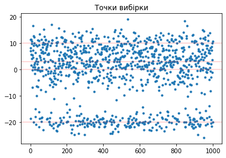

```python
# генеруємо вибірку та дивимося на неї
data = GenerateNormalMix([-20, 0, 3, 10], [2, 5, 4, 3], [1/4, 1/4, 1/4, 1/4], 1000)
plt.plot(data, '.')
plt.title('Точки вибірки')
plt.axhline(-20, alpha=0.2, c='r')
plt.axhline(0, alpha=0.2, c='r')
plt.axhline(3, alpha=0.2, c='r')
plt.axhline(10, alpha=0.2, c='r')
```

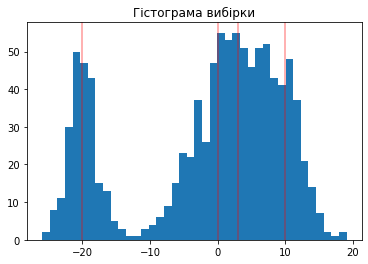

```python
plt.hist(data, 40)
plt.title('Гістограма вибірки')
plt.axvline(-20, alpha=0.4, c='r')
plt.axvline(0, alpha=0.4, c='r')
plt.axvline(3, alpha=0.4, c='r')
plt.axvline(10, alpha=0.4, c='r')
```

## Тестування

Тут одразу виникли проблеми. Деякі точки згенерувались так далеко, що в обчисленнях виникло ділення на 0. Тому знадобилось додати перевірку на занадто малоймовірні точки та викидати їх з обчислень. З цією ж ціллю я викинув фактор $\frac{1}{\sqrt{2\pi}}$ в обчисленнях, бо він все одно має скоротитися

```
m*: [-19.93365242  -1.59284585   3.15638511   9.52301382]
d*: [2.10510968 4.02953212 2.52498419 2.95432097]
p*: [0.22671441 0.26928662 0.2089005  0.29509847]
```

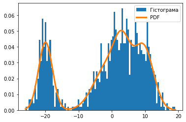

```python
p_true = np.array([1/4, 1/4, 1/4, 1/4])
m_true = np.array([-20, 0, 3, 10])
d_true = np.array([4, 25, 16, 9])

# запускаємо спочатку на правильному значенні p та правильних значеннях m.
# перевіряємо, як алгоритм обчислить дисперсії

d0 = np.array([1,1,1,1])
res, history = EM_Task2(data, p_true, m_true, d0, n_iter=16)
print('m*:', res[0])
print('d*:', res[1])
print('p*:', res[2])
ShowResult(data, *res)
```

```
m*: [-19.93365242  -1.59284585   3.15638511   9.52301382]
d*: [2.10510968 4.02953212 2.52498419 2.95432097]
p*: [0.22671441 0.26928662 0.2089005  0.29509847]
```

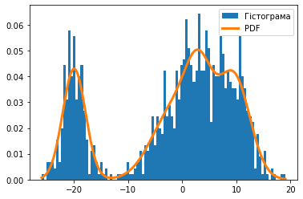

```python
res, history = EM_Task2(data, p_true, m_true, d0, n_iter=16)
print('m*:', res[0])
print('d*:', res[1])
print('p*:', res[2])
ShowResult(data, *res)
```

```
m*: [-19.94118655  -1.49738686   2.92038218   9.43176752]
d*: [2.09603016 4.18402245 2.62023839 3.00872741]
p*: [0.22641076 0.26652078 0.20689132 0.30017715]
```

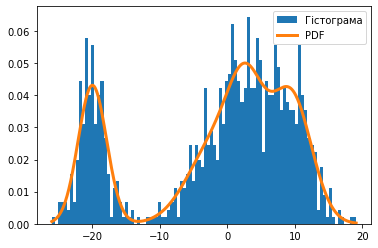

```python
res, history = EM_Task2(data, p_true, m_true, d0, n_iter=32)
print('m*:', res[0])
print('d*:', res[1])
print('p*:', res[2])
ShowResult(data, *res)
```

```
Початкова точка:  [(-20.0, 4), (0.0, 4), (0.1, 4), (10.0, 4)]
m*: [-19.95075317   0.92667466   1.58630193   9.42568288]
d*: [2.08545205 5.23591111 4.409219   3.14368417]
p*: [0.22597736 0.26024037 0.26201935 0.25176292]
```

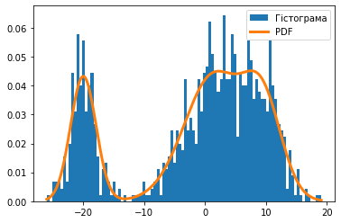

```python
p0 = p_true
m0 = np.array([-20, 0, 0.1, 10])
d0 = np.array([4, 4, 4, 4])

res, history = EM_Task2(data, p0, m0, d0, n_iter=32)
print("Початкова точка: ", list(zip(m0,d0)))
print('m*:', res[0])
print('d*:', res[1])
print('p*:', res[2])
ShowResult(data, *res)
```

```
Початкова точка:  [(-20, 4), (0, 4), (1, 4), (10, 4)]
m*: [-19.97626939   0.04404822   2.08230926   9.59907615]
d*: [2.05678223 5.41672244 3.785855   3.02016307]
p*: [0.2248259  0.25369878 0.26663786 0.25483747]
```

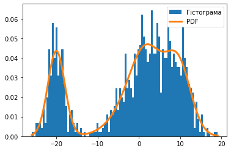

```python
p0 = p_true
m0 = np.array([-20, 0, 1, 10])
d0 = np.array([4, 4, 4, 4])

res, history = EM_Task2(data, p0, m0, d0, n_iter=32)
print("Початкова точка: ", list(zip(m0,d0)))
print('m*:', res[0])
print('d*:', res[1])
print('p*:', res[2])
ShowResult(data, *res)
```

```
Початкова точка:  [(-20, 4), (0, 25), (1, 16), (10, 9)]
m*: [-19.9667863    0.4020291    1.06280956   7.68880774]
d*: [2.06674663 5.0140808  5.20804967 4.14116831]
p*: [0.22529791 0.16813864 0.2582935  0.34826995]
```

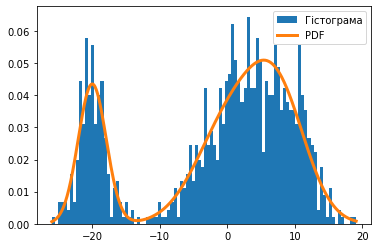

```python
p0 = p_true
m0 = np.array([-20, 0, 1, 10])
d0 = d_true

res, history = EM_Task2(data, p0, m0, d0, n_iter=32)
print("Початкова точка: ", list(zip(m0,d0)))
print('m*:', res[0])
print('d*:', res[1])
print('p*:', res[2])
ShowResult(data, *res)
```

```
Початкова точка:  [(-25, 4), (-1, 25), (2, 16), (6, 9)]
m*: [-19.97910204  -0.21716086   1.24759256   6.74744794]
d*: [2.05327162 5.14398588 5.52658595 4.59996085]
p*: [0.22472112 0.14026075 0.22603275 0.40898538]
```

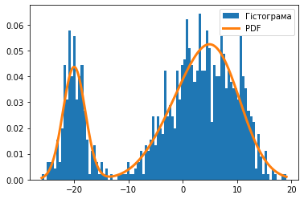

```python
p0 = p_true
m0 = np.array([-25, -1, 2, 6])
d0 = d_true

res, history = EM_Task2(data, p0, m0, d0, n_iter=32)
print("Початкова точка: ", list(zip(m0,d0)))
print('m*:', res[0])
print('d*:', res[1])
print('p*:', res[2])
ShowResult(data, *res)
```

Стійкість:

```
Початкова точка:  [(-20, 4), (0, 25), (3, 16), (10, 9)]
m*: [-19.96022276   1.06523244   2.68499165  10.4136878 ]
d*: [2.07451139 0.23667736 5.50753985 2.16805137]
p*: [0.22556813 0.01249603 0.63711446 0.12482138]
```

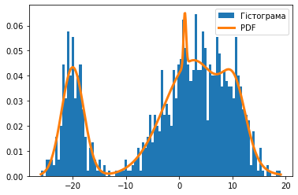

```python
p0 = p_true
m0 = m_true
d0 = d_true

res, history = EM_Task2(data, p0, m0, d0, n_iter=10000)
print("Початкова точка: ", list(zip(m0,d0)))
print('m*:', res[0])
print('d*:', res[1])
print('p*:', res[2])
ShowResult(data, *res)
```

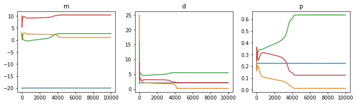

```python
fig, axs = plt.subplots(1,3)
axs[0].plot(history['m'])
axs[0].set_title('m')
axs[1].plot(history['d'])
axs[1].set_title('d')
axs[2].plot(history['p'])
axs[2].set_title('p')
fig.set_size_inches((12,3))
```

І окремо перевірю, як моя реалізація ЕМ алгоритму працюватиме на великій вибірці

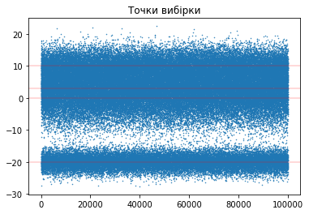

```python
# генеруємо вибірку та дивимося на неї
data = GenerateNormalMix([-20, 0, 3, 10], [2, 5, 4, 3], [1/4, 1/4, 1/4, 1/4], 100000)
plt.plot(data, '.', markersize=1)
plt.title('Точки вибірки')
plt.axhline(-20, alpha=0.2, c='r')
plt.axhline(0, alpha=0.2, c='r')
plt.axhline(3, alpha=0.2, c='r')
plt.axhline(10, alpha=0.2, c='r')
```

```
Початкова точка:  [(-2.0, 1), (0.0, 1), (0.1, 1), (2.0, 1)]
m*: [-19.99372372  -2.90262324  -0.4035465    7.18969251]
d*: [2.01937231 4.15265346 2.61561067 4.27895402]
p*: [0.24963595 0.12623889 0.11201355 0.51211162]
```

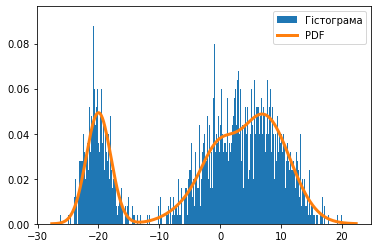

```python
p0 = p_true
m0 = np.array([-2, 0, 0.1, 2])
d0 = np.array([1, 1, 1, 1])

res, history = EM_Task2(data, p0, m0, d0, n_iter=32)
print("Початкова точка: ", list(zip(m0,d0)))
print('m*:', res[0])
print('d*:', res[1])
print('p*:', res[2])
ShowResult(data, *res)
```

Випробував різні початкові точки. найцікавіші спостереження наступні:

- на цих вхідних даних алгоритм працює погано
- алгоритм "бачить" лише $\mathcal N(-20, 4)$ та $\mathcal N(10,9)$ - так як і людина неозброєним оком
- розподіли біля нуля зливаються в один
- алгоритм схильний відправляти багато точок, що не вписуються в модель, в розподіл з матсподіванням 0, великою дисперсією та великим значенням змішуючої ймовірності
- алгоритм нестійкий: якщо подати на вхід еталонні значення, то він з часом відходитиме від них
  - звідси випливає, що іноді збільшення кількості ітерацій не допомагає, а навіть шкодить
- алгоритм дуже залежить від вхідних даних: поведінка та графіки еволюції оцінок якісно відрізняються